# introduction:

# bivariate :

lets take highlook of the correlations between the varables

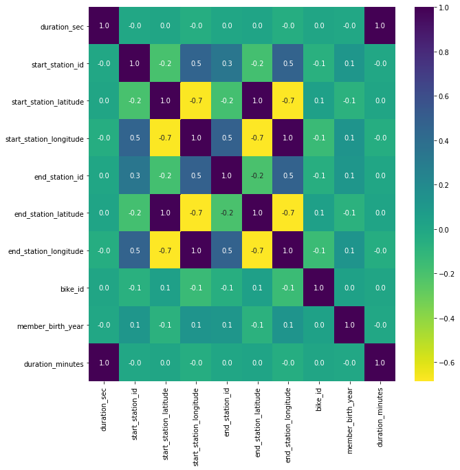

```python
plt.figure(figsize=(10,10));
sns.heatmap(frd_bike.corr(),annot=True,fmt = '.1f',cmap='viridis_r');
```

most of the strong ralations are between the longitude and latitude, but it is pretty clear why they are strong becuse they are represnted by a linear correlation (for the same latitude or longtitude)

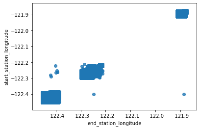

```python
sns.regplot(frd_bike.end_station_longitude,frd_bike.start_station_longitude,fit_reg=False);
```

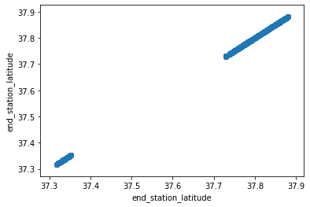

```python
sns.regplot(data=frd_bike,x='end_station_latitude',y='end_station_latitude',fit_reg=False);
```

## it looks most of the numeric variables relations not very intersting so lets look at some relations between different types of variables

## Q: who takes the longest durations males or females ?

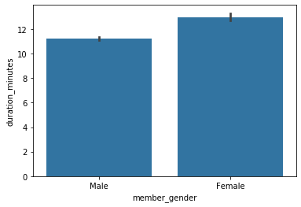

```python
#for gender variable analysis i will focus only on the two main genders so creating a sub-dataframe will be usful
frd_main_genders = frd_bike[frd_bike.member_gender.isin(['Male','Female'])]
sns.barplot(data=frd_main_genders,
            x='member_gender',y='duration_minutes',color=color,dodge=False);
```

### it looks females like to spend more time with bikes more than males

but what if we removed the out liers?

```python
frd_bike.duration_minutes.describe()
```

```
count    174952.000000
mean         11.733379
std          27.370082
min           1.016667
25%           5.383333
50%           8.500000
75%          13.150000
max        1409.133333
Name: duration_minutes, dtype: float64
```

```python
new_max = (13.15-5.383333)*1.5 + 13.15
new_max
```

```
24.800000500000003
```

```python
#this is only created to view the result without outliers
frd_bike_droped = frd_bike[frd_bike.duration_minutes<=new_max]
```

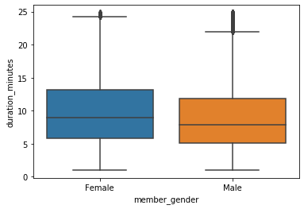

```python
sns.boxplot(data=frd_bike_droped[frd_bike_droped.member_gender.isin(['Male','Female'])]
            ,x='member_gender',y='duration_minutes');
```

### the same result as before females durations are longer

## Q : what is the biger propotion of the (subscribers and customers) in eatch gender?

```python
# count in eatch gender propotions to make sure who has the biger proportions

cus_prop_males = (frd_main_genders[(frd_main_genders.user_type == 'Customer')&(frd_main_genders.member_gender == 'Male')].shape[0]
              / frd_main_genders[frd_main_genders.member_gender == 'Male'].shape[0])
sub_prop_males = 1- cus_prop_males
# do the same for females
cus_prop_females = (frd_main_genders[(frd_main_genders.user_type == 'Customer')&(frd_main_genders.member_gender == 'Female')].shape[0]
              / frd_main_genders[frd_main_genders.member_gender == 'Female'].shape[0])
sub_prop_females = 1- cus_prop_females
[cus_prop_males,sub_prop_males,cus_prop_females,sub_prop_females]
```

```
[0.08806896551724137,
 0.9119310344827586,
 0.11329493934566842,
 0.8867050606543316]
```

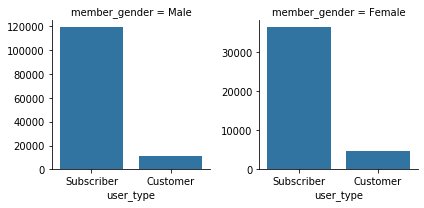

```python
g = sns.FacetGrid(data=frd_main_genders,col='member_gender',sharey=False,);
g.map(sns.countplot, 'user_type',order=['Subscriber','Customer']);
```

in both gender the higher propotion was subscribers

## Q : which gender do more bike-sharing ?

we can use some feature engineering here by using the (bike_share_for_all_trip, member_gender) variables to come up with the (sharing_rate) for each gender

```python
#creating new variale witj numeric values [0,1] for ease the ploting
frd_main_genders.loc[frd_main_genders.bike_share_for_all_trip == 'Yes', 'share'] = 1
frd_main_genders.loc[frd_main_genders.bike_share_for_all_trip == 'No','share' ]= 0
```

```python
means = frd_main_genders.groupby('member_gender').mean()['share'].sort_values(ascending=False)
means
```

```
member_gender
Male      0.100414
Female    0.088077
Name: share, dtype: float64
```

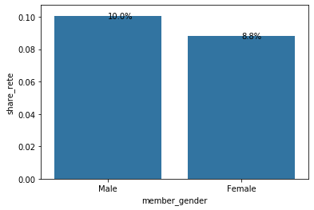

```python
sns.barplot(data=frd_main_genders,x='member_gender',y='share',color=color,errwidth=0);

plt.ylabel('share_rete');
for i in range (means.shape[0]):
    count = means[i]
    pct_string = '{:0.1f}%'.format(100*count)
    plt.text(i, count, pct_string, va='center',)
```

looks males share bikes more than females sense the sharing rates was (10%,8.8%)respectivly

# multivariate :

## Q: the relation between (duration_minutes, member_birth_year & member_gender) ?

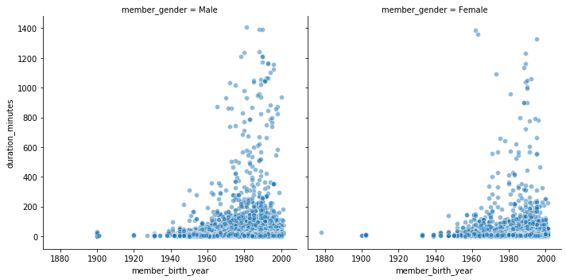

```python
g = sns.FacetGrid(data=frd_main_genders,col='member_gender',size=5);
g.map(sns.scatterplot,'member_birth_year','duration_minutes',alpha=0.5);
```

## Q:how the user type relates to the duration in eatch gender ?

we will use the dropped dataframe to avoid outliers for the purpose of clarity

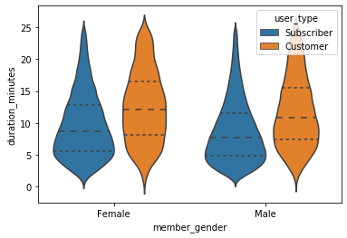

```python
sns.violinplot(data=frd_bike_droped[frd_bike_droped.member_gender.isin(['Male','Female'])]
               ,x='member_gender',y='duration_minutes',hue='user_type',inner='quartile');
```

it seems subscribers spend less time with the bikes than customers in both genders, but females still have higher duration even after dropping outliers.